# Rapport sur la production d’énergie en Europe entre 2016 et 2018

Célia Jourdan

26/10/2021

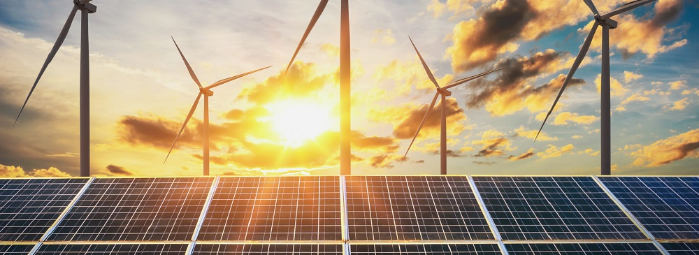

## Description des données

Les données analysées dans ce rapport contiennent des infomations sur la production d’énergie de 37 pays européens entre 2016 et 2018. Ces données sont séparées en deux tableaux :

Le premier tableau contient la quantité d’énergie produite en GWh par type d’énergie, par pays et par année :

```r
kableExtra::kable(energy_types[1:8,], format = "pipe", caption = "energy_type")
```

energy_type

| country | country_name | type | level | 2016 | 2017 | 2018 |
| --- | --- | --- | --- | --- | --- | --- |
| BE | Belgium | Conventional thermal | Level 1 | 30728 | 31316.0 | 30092.635 |
| BE | Belgium | Nuclear | Level 1 | 41430 | 40128.5 | 26995.628 |
| BE | Belgium | Hydro | Level 1 | 1476 | 1360.9 | 1239.248 |
| BE | Belgium | Pumped hydro power | Level 2 | 1110 | 1093.2 | 983.190 |
| BE | Belgium | Wind | Level 1 | 5340 | 6387.9 | 7177.346 |
| BE | Belgium | Solar | Level 1 | 3070 | 3264.3 | 3488.979 |
| BE | Belgium | Geothermal | Level 1 | 0 | 0.0 | 0.000 |
| BE | Belgium | Other | Level 1 | 476 | 490.9 | 218.509 |

Le deuxième tableau renseigne sur la quantité totale d’énergie de niveau 1 produite, importée, exportée, perdue dans le processus de pompage-turbinage ainsi que sur le niveau de la demande, le tout par pays et par année :

```r
kableExtra::kable(country_totals[1:5,], format = "pipe", caption = "country_total")
```

country_total

| country | country_name | type | level | 2016 | 2017 | 2018 |
| --- | --- | --- | --- | --- | --- | --- |
| BE | Belgium | Total net production | Total | 82520 | 82948.5 | 69212.347 |
| BE | Belgium | Imports | Total | 14648 | 14189.4 | 21635.908 |
| BE | Belgium | Exports | Total | 8465 | 8167.8 | 4308.347 |
| BE | Belgium | Energy absorbed by pumping | Total | 1475 | 1485.4 | 1347.901 |
| BE | Belgium | Energy supplied | Total | 87228 | 87484.7 | 85192.007 |

## Questions :

### Partie 1 : Analyse descriptive

#### 1. Quels pays sont pris en compte dans ces données ?

```r
qu1 <- energy_types %>%
  select(country_name) %>%
  distinct()

kableExtra::kable(list(qu1[1:5,],qu1[6:10,],qu1[11:15,],qu1[16:20,], qu1[21:25,],qu1[26:30,], qu1[31:35,], qu1[36:37,]),format = "pipe", col.names = "", caption = "Pays Européens présents dans les données :")
```

Pays Européens présents dans les données :

| Belgium |
| --- |
| Bulgaria |
| Czechia |
| Denmark |
| Germany |

| Estonia |
| --- |
| Ireland |
| Greece |
| Spain |
| France |

| Croatia |
| --- |
| Italy |
| Cyprus |
| Latvia |
| Lithuania |

| Luxembourg |
| --- |
| Hungary |
| Malta |
| Netherlands |
| Austria |

| Poland |
| --- |
| Portugal |
| Romania |
| Slovenia |
| Slovakia |

| Finland |
| --- |
| Sweden |
| NA |
| Norway |
| Montenegro |

| North Macedonia |
| --- |
| Albania |
| Serbia |
| Turkey |
| Bosnia & Herzegovina |

| Ukraine |
| --- |
| Georgia |

On observe une valeur manquante. Lorsqu’on regarde dans le tableau complet on voit qu’il s’agit du Royaume-Uni. On va donc le rajouter :

```r
energy_types[217:224,2] <- "UK"
country_totals[136:140,2] <- "UK"
```

#### 2. Quelle a été la production moyenne en Europe chaque année ?

```r
qu2 <- country_totals %>%
  summarise("Moyenne 2016" = mean(`2016`, na.rm = T), "Moyenne 2017" = mean(`2017`, na.rm = T), "Moyenne 2018" = mean(`2018`, na.rm = T))

kableExtra::kable(qu2, format = "simple")
```

| Moyenne 2016 | Moyenne 2017 | Moyenne 2018 |
| --- | --- | --- |
| 45207.06 | 45413.37 | 45062.34 |

#### 3. Quelle a été l’évolution de la répartition des types d’énergie en Europe entre 2016 et 2018 ?

```r
qu3 <- energy_types %>%
  group_by(type) %>%
  summarise("Prod 2016" = sum(`2016`),"Prod 2017" = sum(`2017`),"Prod 2018" = sum(`2018`))

qu3$type <- c("Conv", "Géoth", "Hydro", "Nucléaire", "Autres", "Pompage", "Solaire", "Eolien")

kableExtra::kable(qu3, format = "simple")
```

| type | Prod 2016 | Prod 2017 | Prod 2018 |
| --- | --- | --- | --- |
| Conv | 1801451.654 | 1838782.375 | 1704429.420 |
| Géoth | 10281.953 | 11393.977 | 12443.754 |
| Hydro | 631263.647 | 564248.938 | 611993.531 |
| Nucléaire | 871560.205 | 866210.980 | 868333.983 |
| Autres | 5670.308 | 5691.438 | 8019.144 |
| Pompage | 32889.277 | 33442.817 | 50153.928 |
| Solaire | 111948.354 | 121909.507 | 130968.490 |
| Eolien | 318809.583 | 379963.520 | 401332.380 |

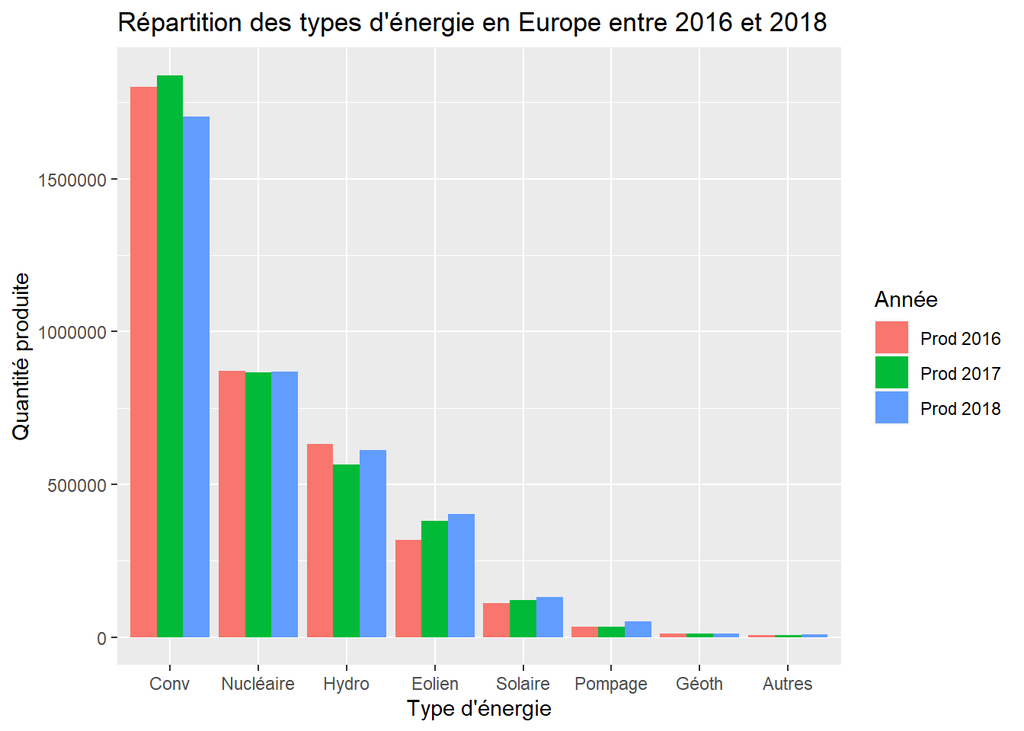

```r
qu3 %>%
  pivot_longer(cols = -type, names_to = "Année", values_to = "prod_totale") %>%
  ggplot(aes(x = reorder(type, -prod_totale), y = prod_totale, fill = Année))+
  geom_col(position = "dodge")+
  labs(x = "Type d'énergie", y = "Quantité produite", title = "Répartition des types d'énergie en Europe entre 2016 et 2018")
```

#### 4. Quelle était la distribution de fréquence des types d’énergie parmi ces pays en 2018 ? C’est-à-dire combien de pays ont produit chaque type d’énergie en 2018 ?

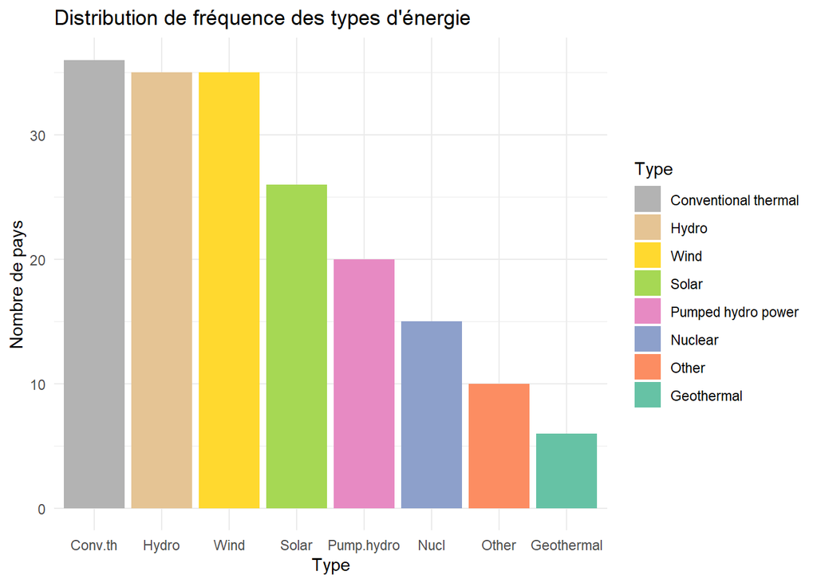

```r
energy_types %>%
  filter(`2018` != 0) %>%
  group_by(type) %>%
  mutate(type2 = case_when(
    type == "Conventional thermal" ~ "Conv.th",
    type == "Nuclear" ~ "Nucl",
    type == "Hydro" ~ "Hydro",
    type == "Pumped hydro power" ~ "Pump.hydro",
    type == "Wind" ~ "Wind",
    type == "Solar" ~ "Solar",
    type == "Geothermal" ~ "Geothermal",
    type == "Other" ~ "Other"),
    n = n()) %>%
  ggplot(aes(x = reorder(type2,-n), fill = reorder(type,-n)))+
  geom_bar()+
  scale_fill_brewer(palette = "Set2", direction = -1)+
  theme_minimal()+
  labs(x = "Type", y = "Nombre de pays", fill = "Type", title = "Distribution de fréquence des types d'énergie")
```

#### 5. Quels sont les 10 pays qui ont produit le plus d’énergies renouvelables par rapport à leur production totale d’énergie en 2018 ?

```r
qu5 <- energy_types %>%
  group_by(country_name) %>%
  mutate(total_2018 = sum(`2018`)) %>%
  filter(type %in% c("Hydro", "Wind", "Solar", "Geothermal", "Other")) %>%
  mutate(total_ren_2018 = sum(`2018`)) %>%
  summarise(pourcent_ren = mean((total_ren_2018/total_2018)*100, na.rm = F)) %>%
  arrange(-pourcent_ren)

kableExtra::kable(qu5[1:10,], format = "html", col.names = c("Pays", "Pourcentage d'énergies renouvelables")) %>%

  kable_styling(bootstrap_options = "striped", full_width = F, position = "left")
```

| Pays | Pourcentage d’énergies renouvelables |
| --- | --- |
| Albania | 100.00000 |
| Norway | 95.37822 |
| Georgia | 82.59128 |
| Croatia | 65.75534 |
| Lithuania | 64.38740 |
| Austria | 62.33691 |
| Montenegro | 61.42132 |
| Denmark | 51.37256 |
| Luxembourg | 50.01534 |
| Sweden | 49.03492 |

#### 6. Quelle était la répartition des types d’énergie en France en 2018 ?

```r
qu6 <- energy_types %>%
  filter(country == "FR") %>%
  select(type, `2018`) %>%
  rename("Type" = type, "Production" = `2018`) %>%
  arrange(-Production)

Renouvelables <- qu6 %>%
  filter(Type %in% c("Wind", "Solar", "Geothermal", "Other")) %>%
  summarise(Production = sum(Production))
Renouvelables <- cbind(Type = "Renewables", Renouvelables[1,1])

camembert <- rbind(qu6, Renouvelables) %>%

  filter(Type %in% c("Conventional thermal", "Nuclear", "Hydro", "Pumped hydro power", "Renewables")) %>%

  ggplot(aes(x = "", y = Production, fill = reorder(Type, Production)))+
  geom_col()+
  scale_fill_brewer(palette = "Greens")+
  coord_polar(theta = "y")+
  theme_void()+
  labs(title = "Répartition des types d'énergie produite en France en 2018", fill = "Type")

kableExtra::kable(qu6, format = "html") %>%

  kable_styling(bootstrap_options = "striped", full_width = F, position = "left")
```

| Type | Production |
| --- | --- |
| Nuclear | 393153.254 |
| Hydro | 68706.552 |
| Conventional thermal | 53956.440 |
| Wind | 26134.020 |
| Solar | 9651.478 |
| Pumped hydro power | 9082.043 |
| Geothermal | 84.084 |
| Other | 0.000 |

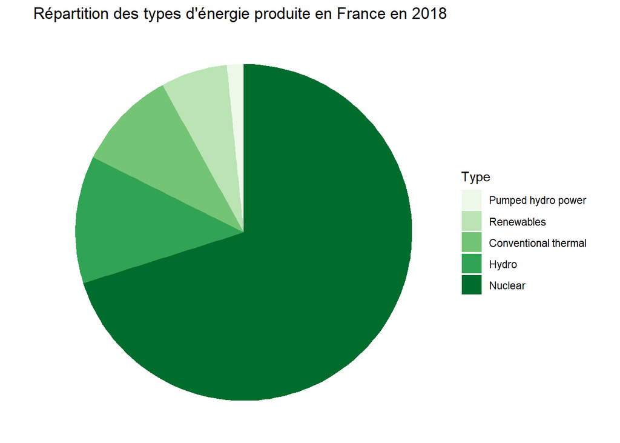

```r
camembert
```

### Partie 2 : Recherche de corrélation entre les variables

Pour simplifier les analyses, nous ne gardons que la quantité de production pour l’année 2018, retirons la colonne “level”, et faisons pivoter le tableau pour que le type devienne une variable :

```r
energy_types2 <- select(energy_types, -`2016`, -`2017`, -level) %>%
  pivot_wider(names_from = type, values_from = `2018`)
country_totals2 <- select(country_totals, -`2016`, -`2017`, -level) %>%
  pivot_wider(names_from = type, values_from = `2018`)
```

#### 7. Le niveau de la demande a-t-il un impact sur le niveau d’importations ?

```r
qu7 <- country_totals2 %>%
  lm(Imports ~ `Energy supplied`,.)

kableExtra::kable(tidy(qu7), format = "pipe")
```

| term | estimate | std.error | statistic | p.value |
| --- | --- | --- | --- | --- |
| (Intercept) | 7296.9521494 | 1819.0867890 | 4.011327 | 0.0003021 |
| `Energy supplied` | 0.0432296 | 0.0110068 | 3.927547 | 0.0003848 |

La p.value est faible donc on a peu de risque de se tromper en affirmant que la demande d’énergie a un impact positif sur les importations. On peut représenter cette relation sur un graphique :

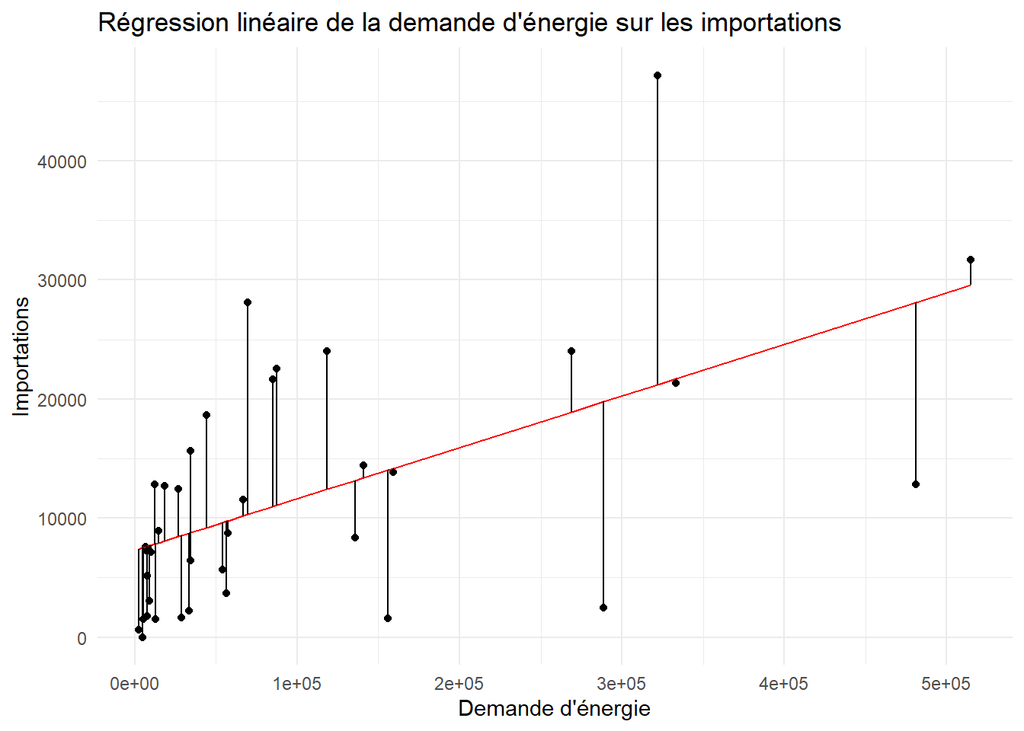

```r
qu7 %>%
  augment() %>%
  ggplot(aes(x = `Energy supplied`, y = Imports))+
  geom_point()+
  geom_line(aes(x = `Energy supplied`, y = .fitted), color = "red")+
  geom_segment(aes(x = `Energy supplied`, xend =  `Energy supplied`, y = Imports, yend = .fitted))+
  theme_minimal()+
  labs(title = "Régression linéaire de la demande d'énergie sur les importations", x = "Demande d'énergie", y = "Importations")
```

#### 8. Y a-t-il une corrélation entre le pourcentage de production d’énergie renouvelable et le pourcentage d’importations ?

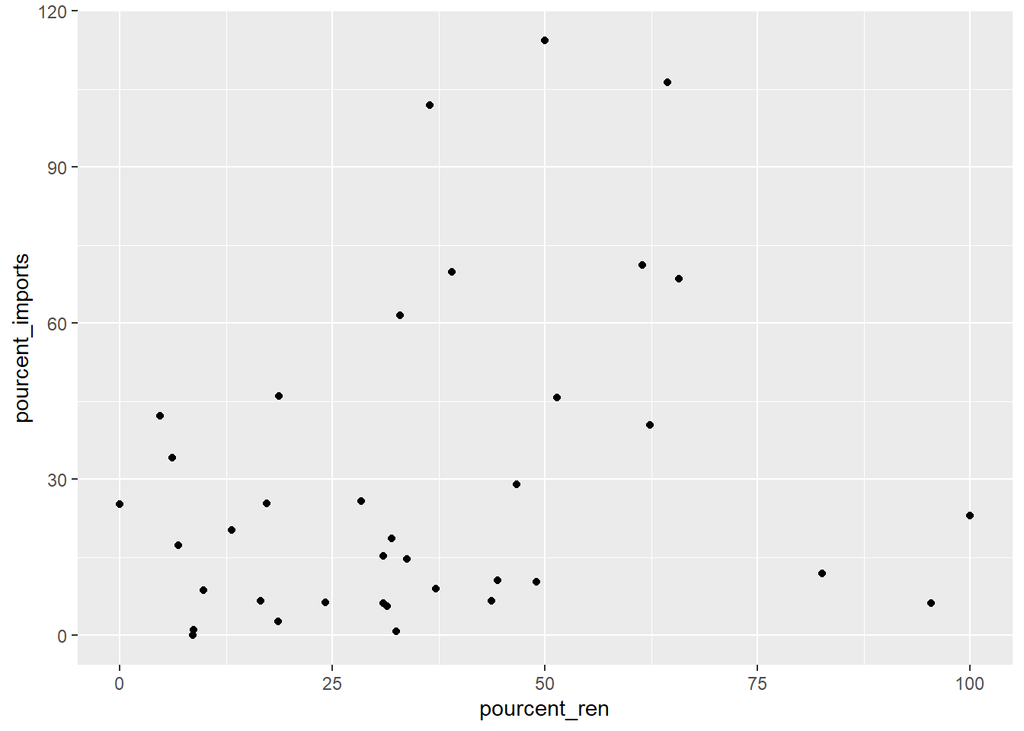

```r
qu8 <- country_totals2 %>%
  left_join(qu5, by = "country_name") %>%
  left_join(energy_types2, by = "country_name") %>%
  mutate(pourcent_imports = (Imports / `Energy supplied`)*100)

qu8 %>%
  ggplot(aes(x = pourcent_ren, y = pourcent_imports))+
  geom_point()
```

On ne voit pas clairement de tendance se dégager mais on peut calculer la corrélation entre les deux variables pour s’en assurer :

```r
kableExtra::kable(tidy(cor.test(qu8$Imports, qu8$pourcent_ren)), format = "pipe")
```

| estimate | statistic | p.value | parameter | conf.low | conf.high | method | alternative |
| --- | --- | --- | --- | --- | --- | --- | --- |
| -0.0762747 | -0.4525655 | 0.6536545 | 35 | -0.3906392 | 0.2540223 | Pearson’s product-moment correlation | two.sided |

# Section par Paolo Crosetto

## Commentaires

Votre présentation était bien mais je l’ai trouvé par parties pas très claire. Sinon, très bien.

## Questions additionnelles

### 1. Dumbbell plot

Mettez l’accent sur l’évolution de l’energy mix. Essayez de faire un grpahique qui compare 2016 et 2018, et montre les variations pour chaque type d’énergie. Références pour un dumbell plot: https://static01.nyt.com/images/2021/03/24/multimedia/24-GENDER-EARNINGSGAP_RACE/24-GENDER-EARNINGSGAP_RACE-mobileMasterAt3x.png ou bien https://econlife.com/wp-content/uploads/2016/07/Dr__Paid_Less__An_Old_Title_Still_Fits_Female_Physicians_-_The_New_York_Times.png C’est à dire un “dotplot” qui montre pour chaque secteur (et sous-secteur) la différence homme/femme. Ce type de plots s’appellent aussi Dumbbell plots, examples ici: http://r-statistics.co/Top50-Ggplot2-Visualizations-MasterList-R-Code.html#3.%20Ranking

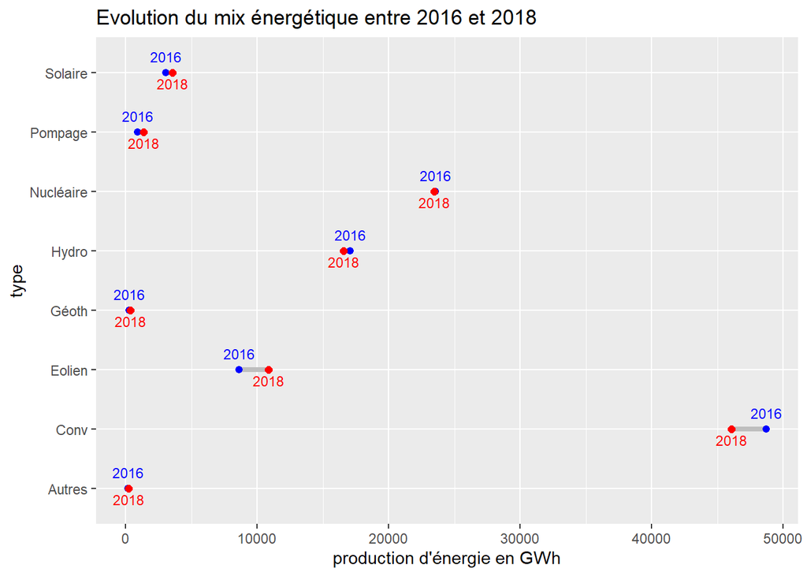

```r
qusup1 <- energy_types %>%
  mutate(total_2016 = sum(`2016`), total_2018 = sum(`2018`)) %>%
  group_by(type) %>%
  summarise(`2016` = mean(`2016`), `2018` = mean(`2018`))
qusup1$type <- c("Conv", "Géoth", "Hydro", "Nucléaire", "Autres", "Pompage", "Solaire", "Eolien")

qusup1 %>%
  ggplot(aes(x = `2016`,xend = `2018`, y = type))+
  geom_dumbbell(colour_x = "blue", colour_xend = "red", size = 1.5, color = "grey")+
  labs(title = "Evolution du mix énergétique entre 2016 et 2018", x = "production d'énergie en GWh")+
  geom_text(aes(x = `2016`, y = type, label = "2016"), color = "blue", size = 3, vjust=-1)+
  geom_text(aes(x = `2018`, y = type, label = "2018"), color = "red", size = 3, vjust=+1.5)
```

### 2. Graphique compact de resumé

Pourriez-vous imaginer une façon d’utiliser `facet` pour faire un graphique des sources d’énergie (ou de la part de renouvelables) par pays? Il n’y a pas tant de pays que ça et cela devrait être faisable. Puet-être vous pourriez étendre le camembert à tous les pays, où imaginer autre chose… Le but étant de donner en en coup d’oeil une panorama de l’Europe et de comme les différents pays se débrouillent. Points additionnels si cela a lieu sur une carte de l’europe, mais pas nécessaire.

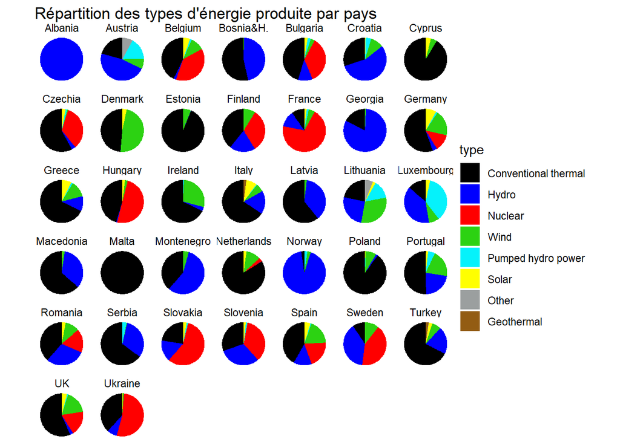

```r
energy_types$country_name[273:280] <- "Bosnia&H."
energy_types$country_name[241:248] <- "Macedonia"

energy_types %>%
  group_by(country_name) %>%
  mutate(total_2018 = sum(`2018`)) %>%
  group_by(type) %>%
  mutate(pourcent = (`2018`/total_2018)*100) %>%
  ggplot(aes(x = "", y = pourcent, fill = reorder(type, -pourcent)))+
  geom_col()+
  facet_wrap(~country_name)+
  scale_fill_manual(values = c("black", "blue", "red", "#2CD212", "#05F2FB", "yellow", "#9B9F9F", "#935C13"))+
  coord_polar(theta = "y")+
  theme_void()+
  labs(title = "Répartition des types d'énergie produite par pays", fill = "type")
```

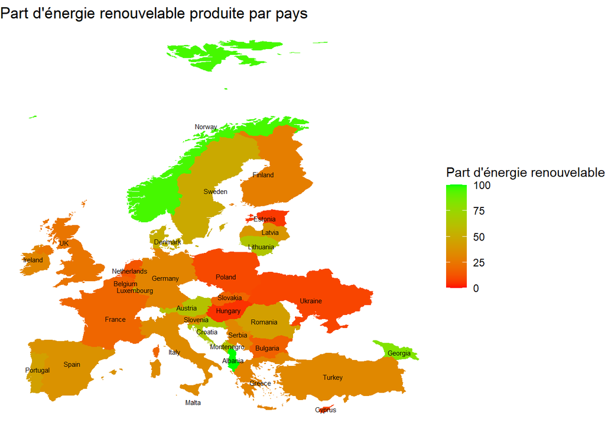

```r
energy_types2 <- energy_types
energy_types2$country_name[273:280] <- "Bosnia and Herzegovina"
energy_types2$country_name[17:24] <-"Czech Republic"

mapdata <- map_data("world", region = energy_types$country_name)

noms_pays <- mapdata %>%
  group_by(region) %>%
  summarise(long = mean(long), lat = mean(lat))

mapdata %>%
  left_join(qu5, by = c("region" = "country_name")) %>%
  ggplot(aes(x = long, y = lat))+
  geom_polygon(aes(group = group, fill = pourcent_ren))+
  geom_text(aes(label = region), data = noms_pays,  size = 2, hjust = 0.5)+
  theme_void()+
  labs(title = "Part d'énergie renouvelable produite par pays", fill = "Part d'énergie renouvelable")+
  scale_fill_gradient(low = "red", high = "green")
```

### 3. Corrélation

Y a-t-il une corrélation entre le fait d’être exportateur/importateur net d’énergie et les types d’énergie produite? Par exemple j’imagine que la France soit très dépendante du nucléaire et *à cause de cela* un exportateur net. Pour bien répondre il faut `join`er les deux bases, créer une variable d’exportateur net, et analyser l’impact de la part de chaque production sur cette variable… et si vous en avez envie fair eun plot qui illustre le résultat, quoi qu’il soit (je ne sais pas le prévoir à l’avance!)

```r
q3 <- country_totals %>%
  select(country, country_name, type, `2018`) %>%
  pivot_wider(names_from = type, values_from = `2018`) %>%
  mutate(exp_net = (Exports - Imports)) %>%
  left_join(energy_types, by =  "country") %>%
  select(country_name.x, type, `2018`, exp_net)

cor_exp_type <- q3 %>%
  group_by(type) %>%
  group_modify(~tidy(cor.test(.$exp_net, .$`2018`)))

kableExtra::kable(cor_exp_type, format = "pipe")
```

| type | estimate | statistic | p.value | parameter | conf.low | conf.high | method | alternative |
| --- | --- | --- | --- | --- | --- | --- | --- | --- |
| Conventional thermal | 0.1221632 | 0.7281811 | 0.4713468 | 35 | -0.2101752 | 0.4291933 | Pearson’s product-moment correlation | two.sided |
| Geothermal | -0.2652312 | -1.6274148 | 0.1126196 | 35 | -0.5426176 | 0.0643151 | Pearson’s product-moment correlation | two.sided |
| Hydro | 0.2776463 | 1.7098014 | 0.0961556 | 35 | -0.0509569 | 0.5520054 | Pearson’s product-moment correlation | two.sided |
| Nuclear | 0.6698883 | 5.3377996 | 0.0000058 | 35 | 0.4417552 | 0.8166484 | Pearson’s product-moment correlation | two.sided |
| Other | -0.0475029 | -0.2813487 | 0.7800997 | 35 | -0.3658902 | 0.2808387 | Pearson’s product-moment correlation | two.sided |
| Pumped hydro power | 0.3942749 | 2.5381726 | 0.0157486 | 35 | 0.0805458 | 0.6369251 | Pearson’s product-moment correlation | two.sided |
| Solar | 0.2710651 | 1.6660167 | 0.1046369 | 35 | -0.0580527 | 0.5470376 | Pearson’s product-moment correlation | two.sided |
| Wind | 0.3538401 | 2.2381407 | 0.0316739 | 35 | 0.0336829 | 0.6081358 | Pearson’s product-moment correlation | two.sided |

On voit que le coefficient le plus significatif est celui du nucléaire. On peut faire un nuage de points pour illustrer cette relation :

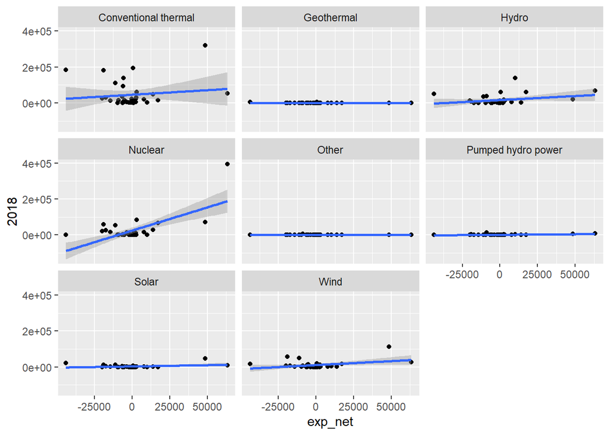

```r
q3 %>%
  ggplot(aes(x = exp_net, y = `2018`))+
  geom_point()+
  geom_smooth(method = "lm")+
  scale_color_brewer(palette = "Set1")+
  facet_wrap(~type)
```

Les graphiques confirment que c’est pour le nucléaire que la relation croissante entre la production d’un type d’énergie en particulier et les exportations nettes est la plus significative.